# Hyperparameters analysis

- Show All Code
- Hide All Code
- View Source

A regression analysis on Optuna study of Mamba architecture

Published

September 12, 2026

## What this does

Loads the Optuna study’s trial history straight from its SQLite storage, keeps only `COMPLETE` trials, builds a design matrix from the searched hyperparameters, and asks two questions:

1. **Which hyperparameters move `mean_val_loss`, and in which direction?** Answered with OLS (linear regression) coefficients, a regularised (ridge) fit, and per-parameter marginal screens.
2. **How co-dependent are the hyperparameters with each other?** Answered with correlation heatmaps, the eigen-spectrum of the design matrix, and variance inflation factors.

`PRUNED` trials were stopped early on a partial `mean_val_loss` and `RUNNING` trials have no final value, so both are excluded.

Log-scale hyperparameters (`learning_rate`, `weight_decay`, `projection_lr_mult` — see `src/config/optuna/mamba2.yaml`) are log-transformed before fitting, since OLS assumes additive linear effects. Categorical hyperparameters are one-hot encoded (first level dropped, absorbed into the intercept). Hyperparameters with no variance across the surviving trials are dropped, OLS cannot estimate an effect for something that never changed.

## Setup

```python
from __future__ import annotations

import warnings
from pathlib import Path
from typing import NamedTuple

import matplotlib as mpl
import matplotlib.pyplot as plt
import numpy as np
import optuna
import pandas as pd
import statsmodels.api as sm
from scipy import stats
from statsmodels.stats.multitest import multipletests

# log-transform Hyperparameters sampled on a log scale (suggest log=True)
LOG_SCALE_PARAMS = {"learning_rate", "weight_decay", "projection_lr_mult"}

# one-hot encode hyperparameters sampled via suggest_categorical
CATEGORICAL_PARAMS = {
    "lr_scheduler",
    "projection_init",
    "d_model",
    "num_hidden_layers",
    "state_size",
    "chunk_size",
}

# The objective is minimised, so a positive coefficient means "raises loss" = worse.
C_WORSE = "#c0392b"
C_BETTER = "#1f77b4"
C_NEUTRAL = "#95a5a6"
C_ACCENT = "#8e44ad"

mpl.rcParams.update({
    "figure.dpi": 130,
    "savefig.dpi": 130,
    "savefig.bbox": "tight",
    "font.size": 9,
    "axes.titlesize": 11,
    "axes.titleweight": "bold",
    "axes.labelsize": 9,
    "axes.spines.top": False,
    "axes.spines.right": False,
    "axes.grid": True,
    "grid.alpha": 0.25,
    "legend.frameon": False,
    "figure.facecolor": "white",
    "axes.facecolor": "white",
})
```

```python
def find_repo_root(marker: str = "pyproject.toml") -> Path:
    for parent in [Path.cwd(), *Path.cwd().parents]:
        if (parent / marker).exists():
            return parent
    return Path.cwd()


STUDY_NAME = "mamba2_rnn_search2"
DB = find_repo_root() / "outputs" / "mamba.db"
assert DB.exists(), f"No such DB: {DB}"
```

## Load the study

```python
optuna.logging.set_verbosity(optuna.logging.WARNING)
study = optuna.load_study(study_name=STUDY_NAME, storage=f"sqlite:///{DB}")

trials = study.trials_dataframe()
complete = (
    trials[(trials["state"] == "COMPLETE") & np.isfinite(trials["value"])]
    .reset_index(drop=True)
    .copy()
)

print(f"study {STUDY_NAME!r}  ({DB})")
print(f"{len(trials)} trials total")
for state, count in trials["state"].value_counts().items():
    print(f"  {state:<10} {count:>3d}")
print(f"\n{len(complete)} COMPLETE trials with a finite value -> used below")
assert len(complete) >= 3, f"Not enough COMPLETE trials to regress on ({len(complete)})"
```

```
study 'mamba2_rnn_search2'  (/Users/carlorosso/Documents/Distiller/outputs/mamba.db)
61 trials total
  PRUNED      39
  COMPLETE    21
  RUNNING      1

21 COMPLETE trials with a finite value -> used below
```

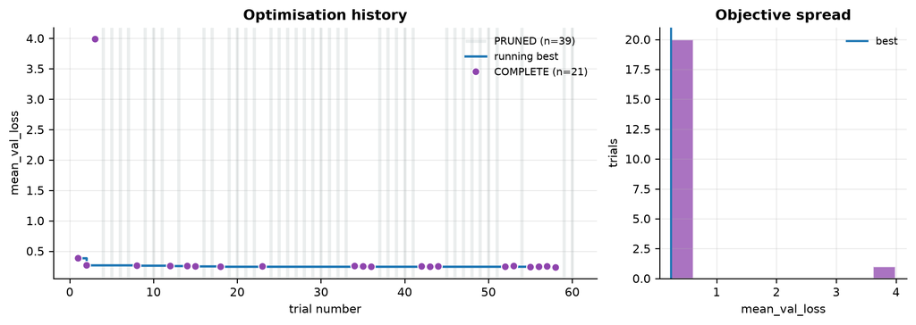

Figure 1: Search progress. Each dot is a COMPLETE trial; the step line is the running best. Vertical bands mark trials the MedianPruner killed early.

```python
fig, axes = plt.subplots(1, 2, figsize=(10, 3.6), width_ratios=[2.2, 1])

ax = axes[0]
order = complete.sort_values("number")
pruned = trials[trials["state"] == "PRUNED"]
ax.vlines(pruned["number"], 0, 1, transform=ax.get_xaxis_transform(),
          color=C_NEUTRAL, alpha=0.18, lw=2.5, label=f"PRUNED (n={len(pruned)})")
ax.step(order["number"], order["value"].cummin(), where="post",
        color=C_BETTER, lw=1.8, label="running best")
ax.plot(complete["number"], complete["value"], "o", color=C_ACCENT, ms=6,
        mec="white", mew=0.8, label=f"COMPLETE (n={len(complete)})")
ax.set_xlabel("trial number")
ax.set_ylabel("mean_val_loss")
ax.set_title("Optimisation history")
ax.legend(loc="upper right", fontsize=8)

ax = axes[1]
ax.hist(complete["value"], bins=min(10, max(3, len(complete) // 2)),
        color=C_ACCENT, alpha=0.75, edgecolor="white")
ax.axvline(complete["value"].min(), color=C_BETTER, lw=1.6, label="best")
ax.set_xlabel("mean_val_loss")
ax.set_ylabel("trials")
ax.set_title("Objective spread")
ax.legend(fontsize=8)

plt.tight_layout()
```

The spread in the right-hand panel is the signal budget: the regression can only explain variation that exists. If every COMPLETE trial landed at nearly the same loss, no hyperparameter can look important, however well-designed the model.

**Warning2 trials dominate the variance**

trial 1 at 0.3866; trial 3 at 3.991 — against a median of 0.2528 across all 21 COMPLETE trials. Dropping them removes **>99% of the variance in the objective**.

This matters more than it looks. Least squares minimises *squared* error, so a single diverged run outweighs all the well-behaved trials combined, and every fit below is largely explaining “which trial blew up” rather than “what makes a good model marginally better”. The rank-based columns in the marginal screens are the outlier-resistant cross-check; if they disagree with the least-squares results, believe them.

## Build the design matrix

```python
class Prepared(NamedTuple):
    X: pd.DataFrame        # encoded design matrix: standardised continuous + dummies
    P: pd.DataFrame        # per-parameter transformed values (log applied, not encoded)
    continuous: list[str]  # original names treated as continuous
    categorical: list[str] # original names treated as categorical
    logged: list[str]      # original names that were log-transformed
    dropped: list[str]     # original names dropped for having no variance


def prepare(df: pd.DataFrame) -> Prepared:
    """Turn the raw params_* columns of a trials dataframe into a numeric, encoded
    design matrix ready for OLS, keeping the intermediate per-parameter values around
    so we can also plot marginal effects on the parameters' own scales."""
    param_cols = [c for c in df.columns if c.startswith("params_")]
    P = df[param_cols].rename(columns=lambda c: c.removeprefix("params_")).copy()

    logged = sorted(LOG_SCALE_PARAMS & set(P.columns))
    for name in logged:
        P[name] = np.log(P[name])

    categorical = [c for c in P.columns if c in CATEGORICAL_PARAMS]
    continuous = [c for c in P.columns if c not in CATEGORICAL_PARAMS]

    # Drop zero-variance columns (a param fixed for this study) -- OLS can't estimate
    # an effect with no variation, and standardising would divide by zero.
    dropped = [c for c in P.columns if P[c].nunique() <= 1]
    P = P.drop(columns=dropped)
    categorical = [c for c in categorical if c not in dropped]
    continuous = [c for c in continuous if c not in dropped]
    logged = [c for c in logged if c not in dropped]

    # Standardise continuous columns so coefficients are comparable in magnitude
    # across hyperparameters with very different natural scales.
    X = P.copy()
    for name in continuous:
        X[name] = (X[name] - X[name].mean()) / X[name].std()
    if categorical:
        X = pd.get_dummies(X, columns=categorical, drop_first=True)

    return Prepared(X.astype(float), P, continuous, categorical, logged, dropped)


prep = prepare(complete)
X, P = prep.X, prep.P
y = complete["value"].rename("mean_val_loss")
n, p = X.shape

print(f"continuous  : {', '.join(prep.continuous) or '-'}")
print(f"  log-scaled: {', '.join(prep.logged) or '-'}")
print(f"categorical : {', '.join(prep.categorical) or '-'}")
print(f"dropped     : {', '.join(prep.dropped) or '-'}  (no variance across COMPLETE trials)")
print(f"\ndesign matrix: n = {n} trials x p = {p} encoded features (+ intercept)")
print(f"OLS residual degrees of freedom: n - p - 1 = {n - p - 1}")
```

```
continuous  : learning_rate, projection_lr_mult, warmup_ratio, weight_decay
  log-scaled: learning_rate, projection_lr_mult, weight_decay
categorical : chunk_size, lr_scheduler, num_hidden_layers, projection_init, state_size
dropped     : batch_size, d_model, num_train_epochs  (no variance across COMPLETE trials)

design matrix: n = 21 trials x p = 10 encoded features (+ intercept)
OLS residual degrees of freedom: n - p - 1 = 10
```

**NoteDegrees of freedom**

```python
X
```

|  | learning_rate | projection_lr_mult | warmup_ratio | weight_decay | chunk_size_256 | lr_scheduler_linear | num_hidden_layers_12 | num_hidden_layers_16 | projection_init_xavier | state_size_64 |
| --- | --- | --- | --- | --- | --- | --- | --- | --- | --- | --- |
| 0 | -0.767793 | 2.017526 | -3.049715 | 1.204677 | 0.0 | 1.0 | 0.0 | 0.0 | 0.0 | 0.0 |
| 1 | 0.087178 | 0.994417 | -0.797846 | -1.287395 | 0.0 | 1.0 | 1.0 | 0.0 | 1.0 | 0.0 |
| 2 | -4.117206 | -2.320636 | -1.852904 | 1.299380 | 1.0 | 0.0 | 1.0 | 0.0 | 1.0 | 0.0 |
| 3 | -0.231659 | 0.209539 | -0.243841 | -1.367139 | 0.0 | 0.0 | 0.0 | 1.0 | 1.0 | 1.0 |
| 4 | 0.476578 | 0.844456 | -0.774125 | -1.509372 | 0.0 | 1.0 | 1.0 | 0.0 | 1.0 | 1.0 |
| 5 | 0.593367 | 0.866310 | 1.252759 | -1.552343 | 0.0 | 1.0 | 1.0 | 0.0 | 1.0 | 1.0 |
| 6 | 0.566379 | 1.368800 | 1.040025 | -0.965199 | 0.0 | 1.0 | 1.0 | 0.0 | 1.0 | 1.0 |
| 7 | -0.077140 | -1.081816 | 0.523338 | 0.273981 | 0.0 | 1.0 | 1.0 | 0.0 | 1.0 | 1.0 |
| 8 | 0.124048 | 0.423185 | 0.794794 | 0.225612 | 0.0 | 1.0 | 1.0 | 0.0 | 1.0 | 1.0 |
| 9 | 0.701532 | 1.082425 | 0.952479 | -1.142156 | 0.0 | 1.0 | 1.0 | 0.0 | 1.0 | 1.0 |
| 10 | 0.139549 | -0.140388 | 0.379448 | -0.572741 | 0.0 | 1.0 | 1.0 | 0.0 | 1.0 | 0.0 |
| 11 | -0.107062 | -0.127138 | 0.200303 | -0.496880 | 1.0 | 1.0 | 1.0 | 0.0 | 1.0 | 0.0 |
| 12 | 0.190714 | -0.167209 | 0.412777 | 0.313256 | 1.0 | 1.0 | 1.0 | 0.0 | 1.0 | 0.0 |
| 13 | 0.289964 | -0.300253 | 0.409676 | 0.735291 | 1.0 | 1.0 | 1.0 | 0.0 | 1.0 | 0.0 |
| 14 | 0.330178 | -1.393431 | 0.167667 | 0.739074 | 1.0 | 1.0 | 1.0 | 0.0 | 1.0 | 0.0 |
| 15 | 0.223490 | -0.058650 | 0.424191 | 0.277103 | 1.0 | 1.0 | 1.0 | 0.0 | 1.0 | 0.0 |
| 16 | -0.037833 | 0.058102 | 0.729752 | -0.274284 | 1.0 | 1.0 | 1.0 | 0.0 | 1.0 | 0.0 |
| 17 | 0.480440 | -0.360844 | 0.041517 | 0.789473 | 1.0 | 1.0 | 1.0 | 0.0 | 1.0 | 0.0 |
| 18 | 0.367059 | -0.374310 | 0.050561 | 1.182435 | 1.0 | 1.0 | 1.0 | 0.0 | 1.0 | 0.0 |
| 19 | 0.461396 | -0.552674 | -0.227257 | 1.273287 | 1.0 | 1.0 | 1.0 | 0.0 | 1.0 | 0.0 |
| 20 | 0.306821 | -0.987412 | -0.433597 | 0.853940 | 1.0 | 1.0 | 1.0 | 0.0 | 1.0 | 0.0 |

## Co-dependency between hyperparameters

Optuna’s TPE sampler is *adaptive*: it concentrates later trials in regions that looked promising earlier. That is exactly what you want from an optimiser, and exactly what you do not want from a regression design — it induces correlation between hyperparameters that a randomised grid would not have. Combined with a small sample, that correlation is what makes individual coefficients unstable, so it is worth measuring directly.

### Pairwise correlation

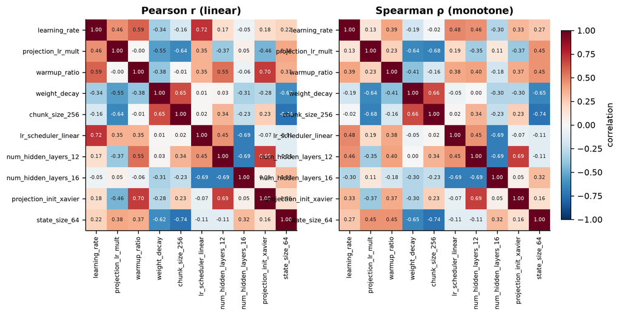

Figure 2: Correlation between encoded design-matrix columns. Off-diagonal cells far from zero mean the two hyperparameters were not explored independently, so the regression cannot cleanly separate their effects.

```python
def heatmap(ax, M: pd.DataFrame, title: str) -> None:
    im = ax.imshow(M.to_numpy(), cmap="RdBu_r", vmin=-1, vmax=1)
    ax.set_xticks(range(M.shape[1]), M.columns, rotation=90, fontsize=7)
    ax.set_yticks(range(M.shape[0]), M.index, fontsize=7)
    ax.set_title(title)
    ax.grid(False)
    if M.shape[0] <= 16:
        for i in range(M.shape[0]):
            for j in range(M.shape[1]):
                v = M.to_numpy()[i, j]
                if np.isfinite(v):
                    ax.text(j, i, f"{v:.2f}", ha="center", va="center", fontsize=5.5,
                            color="white" if abs(v) > 0.62 else "#222222")
    return im


pearson = X.corr()
spearman = X.corr(method="spearman")

fig, axes = plt.subplots(1, 2, figsize=(11, 5.2))
heatmap(axes[0], pearson, "Pearson r (linear)")
im = heatmap(axes[1], spearman, "Spearman ρ (monotone)")
fig.colorbar(im, ax=axes, shrink=0.72, pad=0.02, label="correlation")
```

```python
iu = np.triu_indices_from(pearson.to_numpy(), k=1)
pairs = pd.DataFrame({
    "feature A": pearson.index.to_numpy()[iu[0]],
    "feature B": pearson.columns.to_numpy()[iu[1]],
    "pearson r": pearson.to_numpy()[iu],
    "spearman ρ": spearman.to_numpy()[iu],
})
pairs["|r|"] = pairs["pearson r"].abs()
pairs = pairs.sort_values("|r|", ascending=False).drop(columns="|r|").reset_index(drop=True)
pairs.head(10).round(3)
```

Table 1: The ten most entangled pairs of encoded features.

|  | feature A | feature B | pearson r | spearman ρ |
| --- | --- | --- | --- | --- |
| 0 | chunk_size_256 | state_size_64 | -0.742 | -0.742 |
| 1 | learning_rate | lr_scheduler_linear | 0.723 | 0.482 |
| 2 | warmup_ratio | projection_init_xavier | 0.699 | 0.369 |
| 3 | num_hidden_layers_12 | projection_init_xavier | 0.689 | 0.689 |
| 4 | num_hidden_layers_12 | num_hidden_layers_16 | -0.689 | -0.689 |
| 5 | lr_scheduler_linear | num_hidden_layers_16 | -0.689 | -0.689 |
| 6 | weight_decay | chunk_size_256 | 0.654 | 0.661 |
| 7 | projection_lr_mult | chunk_size_256 | -0.643 | -0.677 |
| 8 | weight_decay | state_size_64 | -0.625 | -0.651 |
| 9 | learning_rate | warmup_ratio | 0.590 | 0.395 |

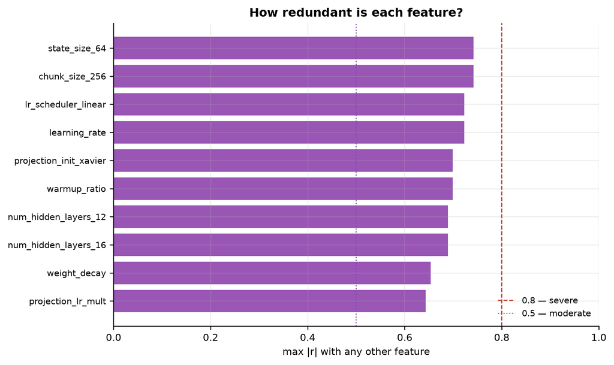

Figure 3: For each feature, the strongest absolute correlation it has with any other feature. Bars near 1.0 mark features that are near-duplicates of some other column — their individual coefficients are essentially arbitrary.

```python
off_diag = pearson.where(~np.eye(p, dtype=bool))
max_abs = off_diag.abs().max().sort_values()

fig, ax = plt.subplots(figsize=(8, 0.34 * p + 1.4))
colors = [C_WORSE if v > 0.8 else (C_ACCENT if v > 0.5 else C_NEUTRAL) for v in max_abs]
ax.barh(range(p), max_abs.to_numpy(), color=colors, alpha=0.9)
ax.set_yticks(range(p), max_abs.index, fontsize=8)
ax.axvline(0.8, color=C_WORSE, ls="--", lw=1, label="0.8 — severe")
ax.axvline(0.5, color=C_ACCENT, ls=":", lw=1, label="0.5 — moderate")
ax.set_xlim(0, 1)
ax.set_xlabel("max |r| with any other feature")
ax.set_title("How redundant is each feature?")
ax.legend(loc="lower right", fontsize=8)
plt.tight_layout()
```

### How many independent directions did the search actually explore?

Pairwise correlation only sees two columns at a time. A feature can be perfectly predictable from a *combination* of others while correlating weakly with each one individually. The eigenvalues of the correlation matrix catch that: each near-zero eigenvalue is one exact linear dependency among the columns.

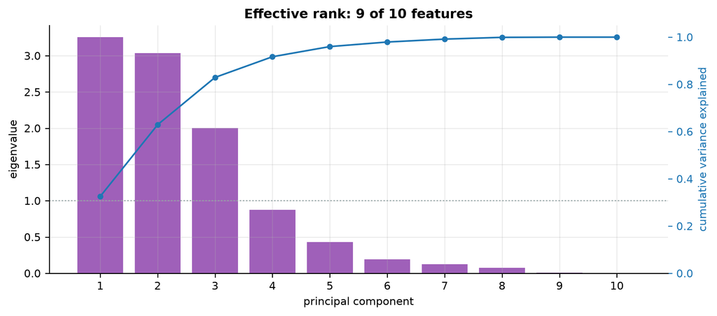

Figure 4: Eigen-spectrum of the feature correlation matrix. Eigenvalues at zero are directions in hyperparameter space that the completed trials never varied independently — each one is a dimension along which the coefficients are unidentifiable.

```python
eig = np.clip(np.sort(np.linalg.eigvalsh(pearson.to_numpy()))[::-1], 0, None)
eff_rank = int((eig > 1e-8).sum())
cum = np.cumsum(eig) / eig.sum()

fig, ax = plt.subplots(figsize=(8.5, 3.8))
bars = ax.bar(range(1, p + 1), eig,
              color=[C_ACCENT if e > 1e-8 else C_WORSE for e in eig], alpha=0.85)
ax.axhline(1.0, color=C_NEUTRAL, ls=":", lw=1)
ax.set_xlabel("principal component")
ax.set_ylabel("eigenvalue")
ax.set_title(f"Effective rank: {eff_rank} of {p} features")
ax.set_xticks(range(1, p + 1))

ax2 = ax.twinx()
ax2.plot(range(1, p + 1), cum, "o-", color=C_BETTER, ms=4, lw=1.4)
ax2.set_ylabel("cumulative variance explained", color=C_BETTER)
ax2.tick_params(axis="y", colors=C_BETTER)
ax2.set_ylim(0, 1.05)
ax2.grid(False)
plt.tight_layout()
```

```python
nonzero = eig[eig > 1e-8]
cond = np.sqrt(eig[0] / nonzero[-1]) if len(nonzero) else np.inf
print(f"effective rank      : {eff_rank} / {p}")
print(f"condition index     : {cond:,.1f}" + ("   (>30 signals serious collinearity)" if np.isfinite(cond) else ""))
print(f"PCs for 90% variance: {int(np.searchsorted(cum, 0.90) + 1)}")
if eff_rank < p:
    print(f"\n{p - eff_rank} exact linear dependencies among the {p} features -- "
          "unavoidable whenever n <= p, since n points span at most n-1 centred dimensions.")
```

```
effective rank      : 9 / 10
condition index     : 18.7   (>30 signals serious collinearity)
PCs for 90% variance: 4

1 exact linear dependencies among the 10 features -- unavoidable whenever n <= p, since n points span at most n-1 centred dimensions.
```

### Variance inflation factors

VIF for feature *j* is `1 / (1 - R²_j)`, where `R²_j` comes from regressing feature *j* on all the others. It is the factor by which co-dependency inflates that coefficient’s variance: VIF > 5 is usually called problematic, VIF > 10 severe.

```python
def vif_table(X: pd.DataFrame) -> pd.DataFrame:
    rows = []
    exog = sm.add_constant(X.to_numpy(), has_constant="add")
    for i, name in enumerate(X.columns):
        others = np.delete(exog, i + 1, axis=1)
        with warnings.catch_warnings():
            warnings.simplefilter("ignore")
            r2 = sm.OLS(X.iloc[:, i].to_numpy(), others).fit().rsquared
        r2 = float(np.clip(r2, 0.0, 1.0)) if np.isfinite(r2) else 1.0
        rows.append({"feature": name, "R² on others": r2,
                     "VIF": np.inf if r2 > 1 - 1e-10 else 1.0 / (1.0 - r2)})
    return pd.DataFrame(rows).sort_values("R² on others", ascending=False).reset_index(drop=True)


vif = vif_table(X)
vif.round(3)
```

Table 2: Variance inflation factors. `R² on others` is the share of each feature that the remaining features already explain.

|  | feature | R² on others | VIF |
| --- | --- | --- | --- |
| 0 | num_hidden_layers_12 | 1.000 | inf |
| 1 | num_hidden_layers_16 | 1.000 | inf |
| 2 | projection_init_xavier | 1.000 | inf |
| 3 | lr_scheduler_linear | 0.981 | 52.468 |
| 4 | learning_rate | 0.967 | 30.485 |
| 5 | projection_lr_mult | 0.857 | 6.983 |
| 6 | weight_decay | 0.823 | 5.641 |
| 7 | chunk_size_256 | 0.812 | 5.327 |
| 8 | warmup_ratio | 0.786 | 4.678 |
| 9 | state_size_64 | 0.777 | 4.486 |

**Warning**

3 of 10 features have infinite VIF — they are exact linear combinations of the others and their coefficients are not separately identifiable.

## OLS fit

```python
with warnings.catch_warnings():
    warnings.simplefilter("ignore")
    np.seterr(divide="ignore", invalid="ignore")
    ols = sm.OLS(y, sm.add_constant(X)).fit()
print(ols.summary())
```

```
                            OLS Regression Results
==============================================================================
Dep. Variable:          mean_val_loss   R-squared:                       1.000
Model:                            OLS   Adj. R-squared:                  1.000
Method:                 Least Squares   F-statistic:                 3.238e+04
Date:                Sat, 12 Sep 2026   Prob (F-statistic):           5.10e-23
Time:                        22:28:29   Log-Likelihood:                 81.945
No. Observations:                  21   AIC:                            -143.9
Df Residuals:                      11   BIC:                            -133.4
Df Model:                           9
Covariance Type:            nonrobust
==========================================================================================
                             coef    std err          t      P>|t|      [0.025      0.975]
------------------------------------------------------------------------------------------
const                      4.1108      0.051     80.326      0.000       3.998       4.223
learning_rate             -0.0037      0.008     -0.440      0.668      -0.022       0.015
projection_lr_mult         0.0028      0.004      0.712      0.491      -0.006       0.012
warmup_ratio              -0.0010      0.003     -0.312      0.761      -0.008       0.006
weight_decay              -0.0025      0.004     -0.694      0.502      -0.010       0.005
chunk_size_256            -0.0056      0.007     -0.818      0.431      -0.021       0.009
lr_scheduler_linear       -3.7328      0.036   -102.653      0.000      -3.813      -3.653
num_hidden_layers_12       1.2013      0.009    137.493      0.000       1.182       1.221
num_hidden_layers_16      -2.5236      0.027    -94.902      0.000      -2.582      -2.465
projection_init_xavier    -1.3223      0.023    -58.072      0.000      -1.372      -1.272
state_size_64             -0.0052      0.007     -0.779      0.452      -0.020       0.009
==============================================================================
Omnibus:                        0.269   Durbin-Watson:                   2.370
Prob(Omnibus):                  0.874   Jarque-Bera (JB):                0.449
Skew:                           0.012   Prob(JB):                        0.799
Kurtosis:                       2.284   Cond. No.                     8.09e+16
==============================================================================

Notes:
[1] Standard Errors assume that the covariance matrix of the errors is correctly specified.
[2] The smallest eigenvalue is 1.3e-32. This might indicate that there are
strong multicollinearity problems or that the design matrix is singular.
```

### Coefficients, visualised

Each coefficient is the change in `mean_val_loss` for a one-standard-deviation increase in that hyperparameter (continuous features, on their log scale where applicable), or for switching to that level from the dropped reference level (dummy features). Because the objective is minimised, **bars to the right are worse and bars to the left are better**.

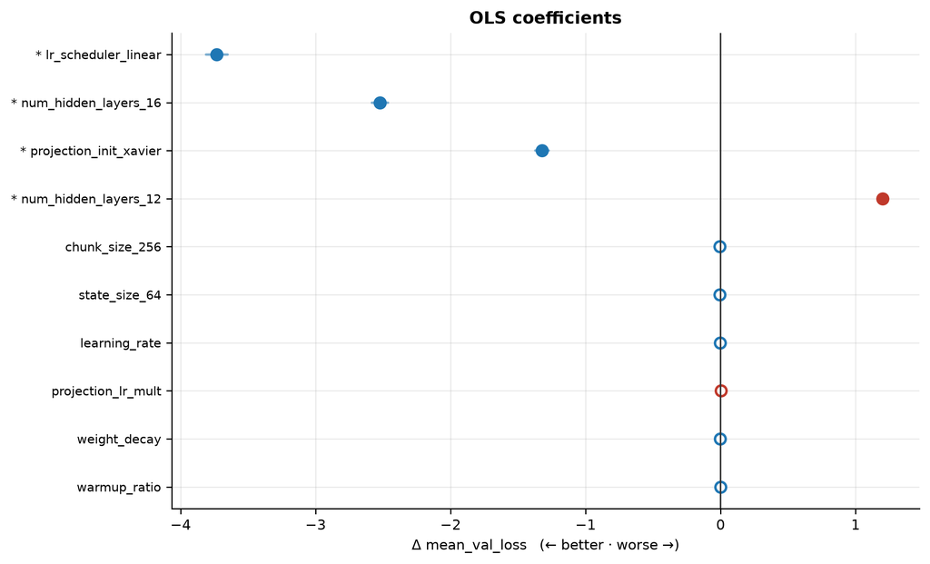

Figure 5: OLS coefficients with 95% confidence intervals, sorted by magnitude. Filled markers are significant at p < 0.05; intervals are omitted where the saturated fit leaves them undefined.

```python
coef = ols.params.drop("const")
try:
    ci = ols.conf_int().drop("const")
    ci.columns = ["lo", "hi"]
except Exception:
    ci = pd.DataFrame({"lo": np.nan, "hi": np.nan}, index=coef.index)
pv = ols.pvalues.drop("const")

order = coef.abs().sort_values().index
coef, ci, pv = coef[order], ci.loc[order], pv[order]
sig = (pv < 0.05).fillna(False)

fig, ax = plt.subplots(figsize=(8.5, 0.36 * len(coef) + 1.6))
pos = np.arange(len(coef))
for i, name in enumerate(coef.index):
    c = C_WORSE if coef[name] > 0 else C_BETTER
    lo, hi = ci.loc[name, "lo"], ci.loc[name, "hi"]
    if np.isfinite(lo) and np.isfinite(hi):
        ax.plot([lo, hi], [i, i], color=c, lw=1.6, alpha=0.55, solid_capstyle="round")
    ax.plot(coef[name], i, "o", ms=7, color=c,
            mfc=c if sig[name] else "white", mew=1.6)

ax.axvline(0, color="#333333", lw=1)
ax.set_yticks(pos, [f"{'* ' if sig[n] else ''}{n}" for n in coef.index], fontsize=8)
ax.set_xlabel("Δ mean_val_loss   (← better · worse →)")
ax.set_title("OLS coefficients" + ("  —  saturated fit, not identified" if n - p - 1 <= 0 else ""))
if not np.isfinite(ci.to_numpy()).any():
    ax.text(0.99, 0.02, "no confidence intervals: 0 residual d.o.f.",
            transform=ax.transAxes, ha="right", va="bottom", fontsize=7.5, color=C_WORSE)
plt.tight_layout()
```

## Ridge: a fit that stays defined when `n ≤ p`

Ridge regression adds an `α‖β‖²` penalty, which makes the coefficients unique even when OLS is saturated, and spreads weight across correlated features instead of letting them cancel each other with huge opposing values. `α` is chosen by leave-one-out cross-validation.

All features are re-standardised for this fit (including the dummies) so the penalty treats them on equal footing and the coefficients are directly comparable.

**NoteWhy the cross-validation is refit from scratch rather than read off the hat matrix**

The textbook shortcut `e₍₋ᵢ₎ = eᵢ / (1 − hᵢᵢ)` recovers leave-one-out residuals from a single fit, and it is exact for ridge — but it is badly misleading when `n ≤ p`. Standardising the columns centres them, so the design matrix spans the same `n − 1` dimensions that centred `y` lives in; at small `α` the model interpolates the training points, the residuals go to zero, and the shortcut duly reports an LOOCV R² of `1.000`. That number measures interpolation, not prediction. With `n` this small an exact refit for every held-out trial costs microseconds, so the honest version is used here — including recomputing the standardisation inside each fold, so no information about the held-out trial leaks into its own prediction.

```python
keep = X.columns[X.std(ddof=0).to_numpy() > 0]
Xa = X[keep].to_numpy()
yv = y.to_numpy()
alphas = np.logspace(-2, 4, 61)


def ridge_fit(X_train: np.ndarray, y_train: np.ndarray, alpha: float):
    """Standardise on the training rows only, then solve the penalised normal equations.
    Returns the coefficients and a predictor that applies the training transform."""
    mu, sd = X_train.mean(0), X_train.std(0)
    sd = np.where(sd > 0, sd, 1.0)
    Z = (X_train - mu) / sd
    y_mean = y_train.mean()
    beta = np.linalg.solve(Z.T @ Z + alpha * np.eye(Z.shape[1]), Z.T @ (y_train - y_mean))
    return beta, lambda X_new: y_mean + ((X_new - mu) / sd) @ beta


def loo_predictions(alpha: float) -> np.ndarray:
    """Exact leave-one-out: refit on the other n-1 trials, predict the held-out one."""
    preds = np.empty(len(yv))
    for i in range(len(yv)):
        mask = np.ones(len(yv), dtype=bool)
        mask[i] = False
        _, predict = ridge_fit(Xa[mask], yv[mask], alpha)
        preds[i] = predict(Xa[i : i + 1])[0]
    return preds


loo_mse = np.array([np.mean((yv - loo_predictions(a)) ** 2) for a in alphas])
best_i = int(np.argmin(loo_mse))
best_alpha = float(alphas[best_i])

y_loo = loo_predictions(best_alpha)
loo_resid_best = yv - y_loo
sst = float(np.var(yv))
r2_loo = 1.0 - loo_mse[best_i] / sst

# Full-data fit at the selected penalty, plus the whole path for the plot below.
beta_best, _ = ridge_fit(Xa, yv, best_alpha)
ridge_coef = pd.Series(beta_best, index=keep)
path = np.array([ridge_fit(Xa, yv, a)[0] for a in alphas])

print(f"best alpha (LOOCV) : {best_alpha:.4g}")
print(f"LOOCV R²           : {r2_loo:.3f}")
print(f"LOOCV RMSE         : {np.sqrt(loo_mse[best_i]):.4f}")
print(f"baseline RMSE      : {np.sqrt(sst):.4f}   (predicting the mean of y every time)")
print(f"best LOOCV R² over the whole alpha grid: {1 - loo_mse.min() / sst:.3f}")
```

```
best alpha (LOOCV) : 316.2
LOOCV R²           : -0.094
LOOCV RMSE         : 0.8321
baseline RMSE      : 0.7955   (predicting the mean of y every time)
best LOOCV R² over the whole alpha grid: -0.094
```

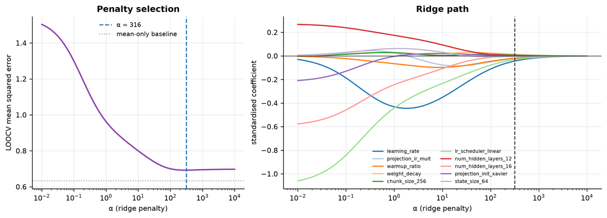

Figure 6: Left: leave-one-out error against penalty strength; the dashed line is the selected α. Right: how each coefficient shrinks as the penalty grows. Coefficients that hold their sign and magnitude across a wide range of α are the robust ones; those that swing wildly at small α are being propped up by collinearity.

```python
fig, axes = plt.subplots(1, 2, figsize=(11, 4), width_ratios=[1, 1.5])

ax = axes[0]
ax.plot(alphas, loo_mse, color=C_ACCENT, lw=1.8)
ax.axvline(best_alpha, color=C_BETTER, ls="--", lw=1.4, label=f"α = {best_alpha:.3g}")
ax.axhline(sst, color=C_NEUTRAL, ls=":", lw=1.2, label="mean-only baseline")
ax.set_xscale("log")
ax.set_xlabel("α (ridge penalty)")
ax.set_ylabel("LOOCV mean squared error")
ax.set_title("Penalty selection")
ax.legend(fontsize=8)

ax = axes[1]
cmap = plt.get_cmap("tab20")
for j, name in enumerate(keep):
    ax.plot(alphas, path[:, j], lw=1.5, color=cmap(j % 20), label=name)
ax.axvline(best_alpha, color="#333333", ls="--", lw=1.2)
ax.axhline(0, color="#333333", lw=0.8)
ax.set_xscale("log")
ax.set_xlabel("α (ridge penalty)")
ax.set_ylabel("standardised coefficient")
ax.set_title("Ridge path")
ax.legend(fontsize=6.5, ncol=2, loc="best")
plt.tight_layout()
```

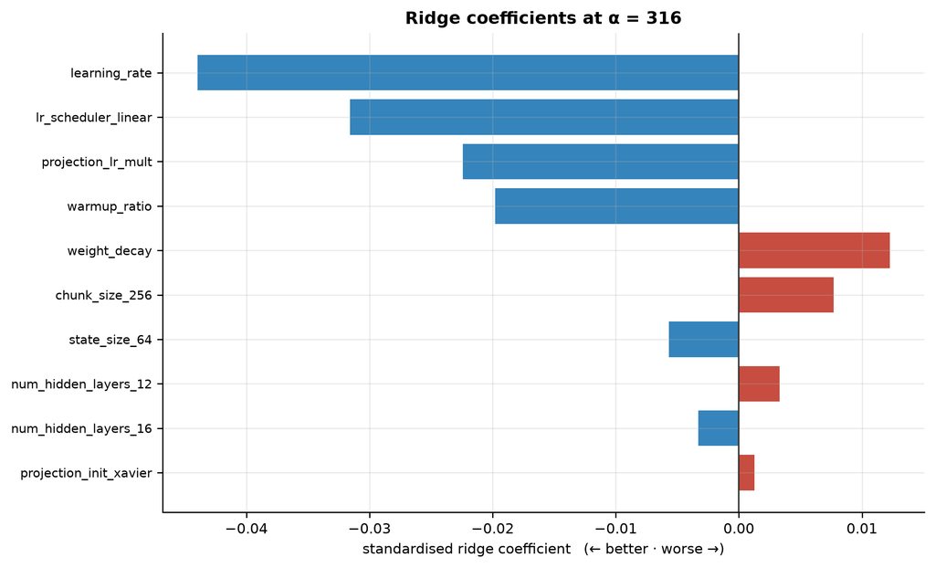

Figure 7: Ridge coefficients at the cross-validated α. These are the most trustworthy per-feature effect estimates available at this sample size — but they are biased toward zero by design, so read them as a ranking rather than as calibrated effect sizes.

```python
rc = ridge_coef.reindex(ridge_coef.abs().sort_values().index)

fig, ax = plt.subplots(figsize=(8.5, 0.36 * len(rc) + 1.6))
ax.barh(range(len(rc)), rc.to_numpy(),
        color=[C_WORSE if v > 0 else C_BETTER for v in rc], alpha=0.9)
ax.axvline(0, color="#333333", lw=1)
ax.set_yticks(range(len(rc)), rc.index, fontsize=8)
ax.set_xlabel("standardised ridge coefficient   (← better · worse →)")
ax.set_title(f"Ridge coefficients at α = {best_alpha:.3g}")
plt.tight_layout()
```

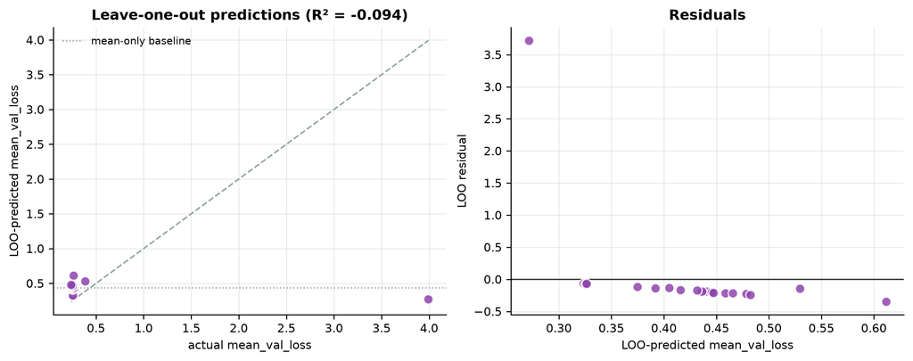

Figure 8: Honest out-of-sample check: each trial’s objective predicted by a ridge model that never saw that trial. Points on the dashed line are perfect predictions.

```python
fig, axes = plt.subplots(1, 2, figsize=(10, 4))

ax = axes[0]
lims = [min(y.min(), y_loo.min()), max(y.max(), y_loo.max())]
pad = 0.05 * (lims[1] - lims[0] or 1)
ax.plot(lims, lims, "--", color=C_NEUTRAL, lw=1.2)
ax.axhline(y.mean(), color=C_NEUTRAL, ls=":", lw=1, label="mean-only baseline")
ax.scatter(y, y_loo, s=55, color=C_ACCENT, alpha=0.85, edgecolor="white", zorder=3)
ax.set_xlim(lims[0] - pad, lims[1] + pad)
ax.set_xlabel("actual mean_val_loss")
ax.set_ylabel("LOO-predicted mean_val_loss")
ax.set_title(f"Leave-one-out predictions (R² = {r2_loo:.3f})")
ax.legend(fontsize=8)

ax = axes[1]
ax.axhline(0, color="#333333", lw=1)
ax.scatter(y_loo, loo_resid_best, s=55, color=C_ACCENT, alpha=0.85,
           edgecolor="white", zorder=3)
ax.set_xlabel("LOO-predicted mean_val_loss")
ax.set_ylabel("LOO residual")
ax.set_title("Residuals")
plt.tight_layout()
```

**ImportantNegative LOOCV R² (-0.094)**

The model predicts held-out trials **worse than simply guessing the mean** of the other trials. With 21 trials, 10 features and the collinearity measured above, there is not yet enough signal to support *any* claim about which hyperparameters matter — including the rankings plotted above. Everything in this document is descriptive until this number turns positive.

## Marginal screens, one hyperparameter at a time

The fits above ask “what does this hyperparameter do *holding the others fixed*” — the question co-dependency makes hard to answer. A marginal screen asks the easier question: “does this hyperparameter alone track the objective at all?” Each test uses a single parameter, so it is well-posed even at this sample size. The cost is confounding: an apparent effect may belong to a correlated parameter instead. p-values are adjusted across parameters with Benjamini–Hochberg FDR.

Each parameter gets two tests. The least-squares column (`p`) is the usual one. The rank column (`p (rank)`) — Spearman for continuous parameters, Kruskal–Wallis for categorical ones — depends only on the ordering of the trials, so a single diverged run cannot drive it. Given the outlier flagged earlier, the rank column is the one to trust.

```python
rows = []
for name in prep.continuous + prep.categorical:
    if name in prep.categorical:
        Xu = pd.get_dummies(P[name], drop_first=True).astype(float)
        means = y.groupby(P[name].to_numpy()).mean()
        counts = P[name].value_counts()
        effect = float(means.max() - means.min())
        # Show the per-level trial count: a level seen once cannot be told apart from
        # whatever else was special about that single trial.
        detail = ", ".join(f"{lvl}={m:.4f} (n={counts[lvl]})"
                           for lvl, m in means.sort_values().items())
        groups = [y[P[name] == lvl].to_numpy() for lvl in P[name].unique()]
        try:
            rank_p = float(stats.kruskal(*groups).pvalue)
        except ValueError:
            rank_p = np.nan
    else:
        Xu = ((P[name] - P[name].mean()) / P[name].std()).to_frame()
        span = f"{P[name].min():.3g}..{P[name].max():.3g}"
        detail = f"log-scaled, {span}" if name in prep.logged else span
        rank_p = float(stats.spearmanr(P[name], y).pvalue)
    with warnings.catch_warnings():
        warnings.simplefilter("ignore")
        m = sm.OLS(y, sm.add_constant(Xu)).fit()
    if name not in prep.categorical:
        effect = float(m.params.iloc[1])
    rows.append({"parameter": name,
                 "kind": "categorical" if name in prep.categorical else "continuous",
                 "effect": effect, "R²": m.rsquared, "p": m.f_pvalue,
                 "p (rank)": rank_p, "detail": detail})

marginal = pd.DataFrame(rows)
ok = np.isfinite(marginal["p"])
marginal["p (BH)"] = np.nan
if ok.any():
    marginal.loc[ok, "p (BH)"] = multipletests(marginal.loc[ok, "p"], method="fdr_bh")[1]
marginal = marginal.sort_values("p").reset_index(drop=True)
marginal[["parameter", "kind", "effect", "R²", "p", "p (rank)", "p (BH)", "detail"]].round(4)
```

Table 3: Per-parameter screens. `effect` is the per-standard-deviation slope for continuous parameters and the spread between best and worst group mean for categorical ones; negative means lower loss. `p` is least-squares, `p (rank)` is the outlier-resistant equivalent, `p (BH)` is `p` after Benjamini-Hochberg FDR correction.

|  | parameter | kind | effect | R² | p | p (rank) | p (BH) | detail |
| --- | --- | --- | --- | --- | --- | --- | --- | --- |
| 0 | learning_rate | continuous | -0.7754 | 0.9048 | 0.0000 | 0.1344 | 0.0000 | log-scaled, -11.4..-6.92 |
| 1 | lr_scheduler | categorical | 1.8700 | 0.4761 | 0.0005 | 0.0417 | 0.0024 | linear=0.2581 (n=19), cosine=2.1280 (n=2) |
| 2 | projection_lr_mult | continuous | -0.4174 | 0.2622 | 0.0176 | 0.0646 | 0.0529 | log-scaled, -1.56..1.64 |
| 3 | warmup_ratio | continuous | -0.3675 | 0.2033 | 0.0403 | 0.3218 | 0.0906 | 0.000752..0.0998 |
| 4 | weight_decay | continuous | 0.2466 | 0.0915 | 0.1826 | 0.2942 | 0.3288 | log-scaled, -9.17..-4.26 |
| 5 | chunk_size | categorical | 0.3189 | 0.0401 | 0.3842 | 0.0573 | 0.5764 | 128=0.2691 (n=10), 256=0.5880 (n=11) |
| 6 | state_size | categorical | 0.2719 | 0.0260 | 0.4853 | 0.3706 | 0.6240 | 64=0.2549 (n=7), 32=0.5268 (n=14) |
| 7 | projection_init | categorical | 0.0520 | 0.0002 | 0.9522 | 0.1372 | 0.9769 | pca=0.3866 (n=1), xavier=0.4386 (n=20) |
| 8 | num_hidden_layers | categorical | 0.1830 | 0.0026 | 0.9769 | 0.1552 | 0.9769 | 16=0.2647 (n=1), 4=0.3866 (n=1), 12=0.4478 (n=19) |

**TipWhere the two tests disagree**

- `learning_rate`, `warmup_ratio` look decisive by least squares but not by rank — the apparent effect rests on the outlying trial rather than on a consistent trend.
- `projection_init`, `num_hidden_layers` have a level observed in only one trial. Its effect is perfectly confounded with everything else that was unique to that trial and cannot be estimated separately.

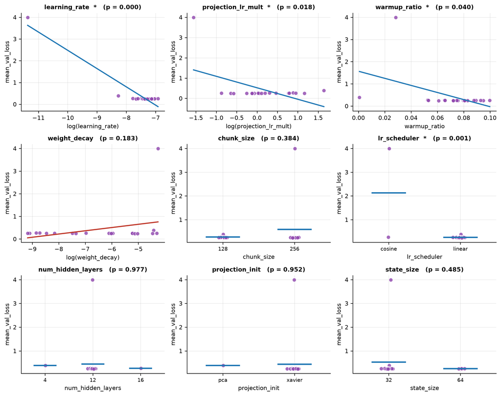

Figure 9: Every non-constant hyperparameter against the objective. Continuous parameters show the simple least-squares line; categorical ones show per-level trial values with the group mean as a bar. Lower is better throughout.

```python
names = prep.continuous + prep.categorical
ncol = 3
nrow = int(np.ceil(len(names) / ncol))
fig, axes = plt.subplots(nrow, ncol, figsize=(11, 2.9 * nrow), squeeze=False)
pv_by_name = marginal.set_index("parameter")["p"]

for ax, name in zip(axes.ravel(), names):
    pval = pv_by_name.get(name, np.nan)
    strong = np.isfinite(pval) and pval < 0.05
    if name in prep.categorical:
        levels = sorted(P[name].unique())
        for i, lvl in enumerate(levels):
            vals = y[P[name] == lvl].to_numpy()
            jitter = np.random.default_rng(0).normal(0, 0.045, len(vals))
            ax.plot(np.full(len(vals), i) + jitter, vals, "o", ms=6,
                    color=C_ACCENT, alpha=0.8, mec="white", mew=0.7)
            ax.hlines(vals.mean(), i - 0.24, i + 0.24, color=C_BETTER, lw=2.2)
        ax.set_xticks(range(len(levels)), [str(v) for v in levels], fontsize=8)
        ax.set_xlim(-0.5, len(levels) - 0.5)
        ax.set_xlabel(name)
    else:
        xv = P[name].to_numpy()
        ax.plot(xv, y, "o", ms=6, color=C_ACCENT, alpha=0.8, mec="white", mew=0.7)
        if len(np.unique(xv)) > 1:
            b1, b0 = np.polyfit(xv, y.to_numpy(), 1)
            xs = np.linspace(xv.min(), xv.max(), 50)
            ax.plot(xs, b0 + b1 * xs, "-", lw=1.8,
                    color=C_WORSE if b1 > 0 else C_BETTER)
        ax.set_xlabel(f"log({name})" if name in prep.logged else name)
    ax.set_ylabel("mean_val_loss")
    ax.set_title(f"{name}{'  *' if strong else ''}   (p = {pval:.3f})" if np.isfinite(pval) else name,
                 fontsize=9.5)

for ax in axes.ravel()[len(names):]:
    ax.axis("off")
plt.tight_layout()
```

## Cross-check: Optuna’s own importance estimate

Optuna scores importance with a tree-based, non-linear evaluator over the same completed trials. It can pick up interactions and thresholds that a linear model cannot, so agreement with the ridge ranking is reassuring and disagreement usually points at a non-linear effect.

```python
try:
    with warnings.catch_warnings():
        warnings.simplefilter("ignore")
        imp = pd.Series(optuna.importance.get_param_importances(study)).sort_values()
    fig, ax = plt.subplots(figsize=(8.5, 0.36 * len(imp) + 1.4))
    ax.barh(range(len(imp)), imp.to_numpy(), color=C_ACCENT, alpha=0.9)
    ax.set_yticks(range(len(imp)), imp.index, fontsize=8)
    ax.set_xlabel("relative importance")
    ax.set_title("Optuna param importances")
    for i, v in enumerate(imp.to_numpy()):
        ax.text(v, i, f" {v:.3f}", va="center", fontsize=7.5)
    plt.tight_layout()
except Exception as exc:
    print(f"Optuna importance evaluation unavailable: {type(exc).__name__}: {exc}")
```

```
Optuna importance evaluation unavailable: ImportError: Tried to import 'sklearn' but failed. Please make sure that the package is installed correctly to use this feature. Actual error: No module named 'sklearn'.
```

## Verdict

- **Sample:** 61 trials run, **21 usable** (39 pruned, 1 still running) against 10 encoded features.
- **Identifiability:** OLS has 10 residual degrees of freedom; the design matrix has effective rank 9/10.
- **Strongest co-dependency:** `chunk_size_256` ↔︎ `state_size_64` at r = -0.74.
- **Predictive signal:** ridge LOOCV R² = -0.094 (does not beat the mean-only baseline).
- **Largest ridge effects:** `learning_rate` (-0.0440), `lr_scheduler_linear` (-0.0316), `projection_lr_mult` (-0.0224).
- **Marginal screens surviving FDR < 0.05:** `learning_rate`, `lr_scheduler`
- **Outlier-resistant rank screens with p < 0.05:** `lr_scheduler`

### How to read all of this

The three fits answer progressively weaker but progressively more reliable questions. OLS gives unbiased partial effects but needs `n` well above `p`. Ridge stays defined under collinearity and small samples, at the price of shrinking effects toward zero, so its coefficients rank rather than measure. The marginal screens are always estimable but ignore confounding entirely. When all three agree on a parameter, that is a real finding; when only one does, it is a hypothesis for the next search round.

The single most effective way to sharpen every number above is more `COMPLETE` trials — not more hyperparameters. The search currently spends most of its budget on trials the pruner kills, which produce no usable objective value; raising `n_warmup_steps` on the `MedianPruner` in `src/config/optuna/mamba2.yaml` trades wall-clock time for the statistical power this analysis is short of.